# Spatio-Temporal Distribution of COPD Mortality in England

By Group 2: CIDs 01818596, XXX, XXX

03/04/2020

Abstract

# 1. Introduction

Chronic obstructive pulmonary disease (COPD), a highly life-threatening lung disease burden particularly among older people worldwide, is characterized by chronic obstruction of lung airflow that interferes with normal breathing and is not fully reversible (Johnson et al. (2020)). In 2004 the World Health Organization (WHO) estimated there were approximately 64 million COPD patients and 3 million deaths due to COPD (Agusti et al. (2010)). The most significant risk factor is long-term tobacco smoking, and additional risk factors include air pollution and occupational exposures (Agusti et al. (2010)). In England, COPD as one of respiratory diseases is the third biggest cause of death (Johnson et al. (2020)). According to NHS, the annual economic burden of COPD in the UK is estimated £1.9 billion (Johnson et al. (2020)). Therefore, combating the threat of COPD have been the top priority of public health in the UK. The understanding of geographical trend helps policy makers more clearly target vulnerable groups and areas with needs improving the prevention and treatment of COPD.

There have been some studies related to the geographical trends of COPD. Hansell et al. (2003) showed that COPD mortality and GP prescriptions for COPD were higher in urban areas compared rural areas, and northern regions in England. Hacking, Muller, and Buchan (2011), Hansell et al. (2003), and Wells and Gordon (2008) demonstrated that there is a significant difference of morbidity and mortality of COPD between regions over the past 40 years.

In recent years, Bayesian hierarchical framework and models have been commonly and extensively applied in epidemiological studies, which enable us to summarise the spatial and temporal variations of disease risk (Boulieri, Hansell, and Blangiardo (2016)). Nandram, Sedransk, and Pickle (2000) used Bayesian analysis and mapping of mortality rates for COPD. Holt et al. (2011) demonstrated the geographic disparities pattern in COPD hospitalization rate and risk due to regionally shared environmental risk factors. Lipton and Banerjee (2006) also investigated the geographical pattern of COPD mortality rate. Hemming et al. (2009) investigated the factors, including temperature, air-pollution, urbanization, income and education, and gas emission, helping predict COPD hospital admission in the UK by using Bayesian network model.

However, most of previous spatial analysis studies focusing on COPD in England or the UK were limited in terms of time window or study population. This project aims to analyse a large and long-term, representative data in England from the Health and Social Care Information Centre, investigating trends in COPD at the population level across England by using Bayesian hierarchical framework to help understanding geographical and temporal distribution of COPD mortality.

# 2. Methods

## 2-1. Outcome measures

Main outcome measure was the spatio-temporal age standardised mortality ratio (SMR) of COPD in England across 323 local unitary authorities (LUAs) between 2001 and 2010.

## 2-2. Data

The number of deaths from COPD in each LUA in each year was obtained from the Health and Social Care Information Centre. Corresponding expected number of deaths from COPD was also used to calculate the crude SMR and for the Baysian modelling.

## 2-3. Statistical Analysis

Firstly, we calculated crude SMRs by simply dividing the observed number of deaths by expected number. We calculated both SMR in each LUA in each year and SMRs over the ten years, and we mapped them.

Secondly, we employed several Bayesian modellings. We tried (1) Spatial model, (2) Spatio-temporal model without space-time interaction nor unstructured temporal variations, (3) Spatio-temporal model without space-time interaction but with unstructured temporal variations, and then (4) Spatio-temporal model with space-time interaction. We compared the fitting of these models by using deviance information criterion (DIC).

In the final model we used a Poisson distribution to model the number of mortality from COPD $O_{it}$, in area $i$ at time $t$. We included a temporal dependence term, which can be modelled using a non-stationary random walk prior: $\xi_{i} \sim \text{N}(\xi_{i-1}, \sigma^2_{\xi})$. We also assumed a space-time interaction, but only type 1 interaction which is between unstructured spatial variations and unstructured temporal variations (Knorr-Held (2000)). The model specification is as below:
$$\begin{eqnarray}
O_{it} & \sim & \text{Poisson}(E_{it}\lambda_{it} ) \\
\log(\lambda_{it}) & = & \alpha + V_{i} + U_{i} + \xi_{t} + \nu_{it}\\
V_{i} & \sim & N(0,1/\tau_{v})\\
{\bf U} & \sim & \hbox{ICAR}({\bf W}, \sigma_u^2)\\
\xi_{t} & \sim & RW(1)\\
\nu_{it} & \sim & N(0,1/\tau_{\nu})\\
\end{eqnarray}$$

where $E_{it}$ is an expected number of mortality from COPD in area $i$ at time $t$ adjusted for age, $V_{i}$ is the unstructured spatial variation in area $i$, $U_{i}$ is the structured spatial variation in area $i$ characterized by Intrinsic Conditional Auto-Regressive (ICAR) model, $\xi_{t}$ is structured temporal variation at time $t$, and $\nu_{it}$ is the interaction term in area $i$ at time $t$.

We investigated the spatio-temporal pattern of COPD mortality visually using the map and the temporal trend graph created. We sought whether there is any LUA that had unusual temporal trends by plotting smoothed SMRs over study period and making a table which contains the worst 5 LUAs in terms of crude and smoothed SMRs.

# 3. Results

In this section, we present the results of crude SMR calculation and one out of four models employed, which is spatio-temporal model with interaction (Model 4). The reasons for selecting this model are twofold. Firstly, this model yielded the lowest DIC out of the three models considering the temporal pattern (Table 1). A lower DIC value indicated that the model had a better balance of model fit and simplicity. Secondly, the space-time interaction allowed us to highlight areas with unusual temporal trend patterns. Because Model 3 did not present lower DIC than model 2, unstructured temporal pattern was thought to be negligible and was not included in the finally selected Model 4.

Table 1: DIC of each model (Model 2; Spatio-temporal model without interaction nor unstructured temporal pattern, Model 3; Spatio-temporal model without interaction but with unstructured temporal pattern, Model 4; Spatio-temporal model with space-time interaction)

|  | Model2 | Model3 | Model4 (Final) |
| --- | --- | --- | --- |
| DIC | 22250 | 22350 | 22190 |

## 3-1. Crude SMRs

Figure 1 shows the SMR summed by time (left) and areas (right). We can see hotspots in northern areas and a general downward trend over time but cannot distinguish areal and temporal patterns in these graphs.

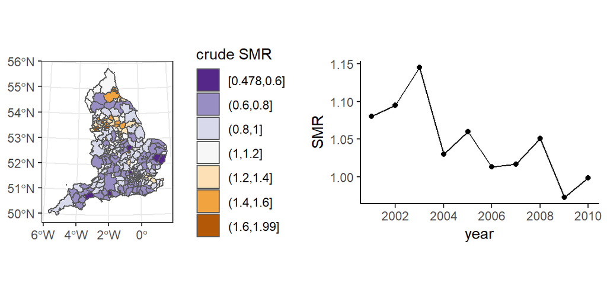

Figure 1: (left) Crude SMR (2001 to 2010 in total), (right) Crude SMR trend

Figure 2 shows the map of SMR in each year during the study period. The general spatial pattern (high in northern ULAs) seems constant but it is difficult to distinguish usual and unusual trend. Figure 3 is a plot of crude SMR of each LUA over time. Again, it is difficult to assess which LUA follows a usual trend and which does an unusual one.

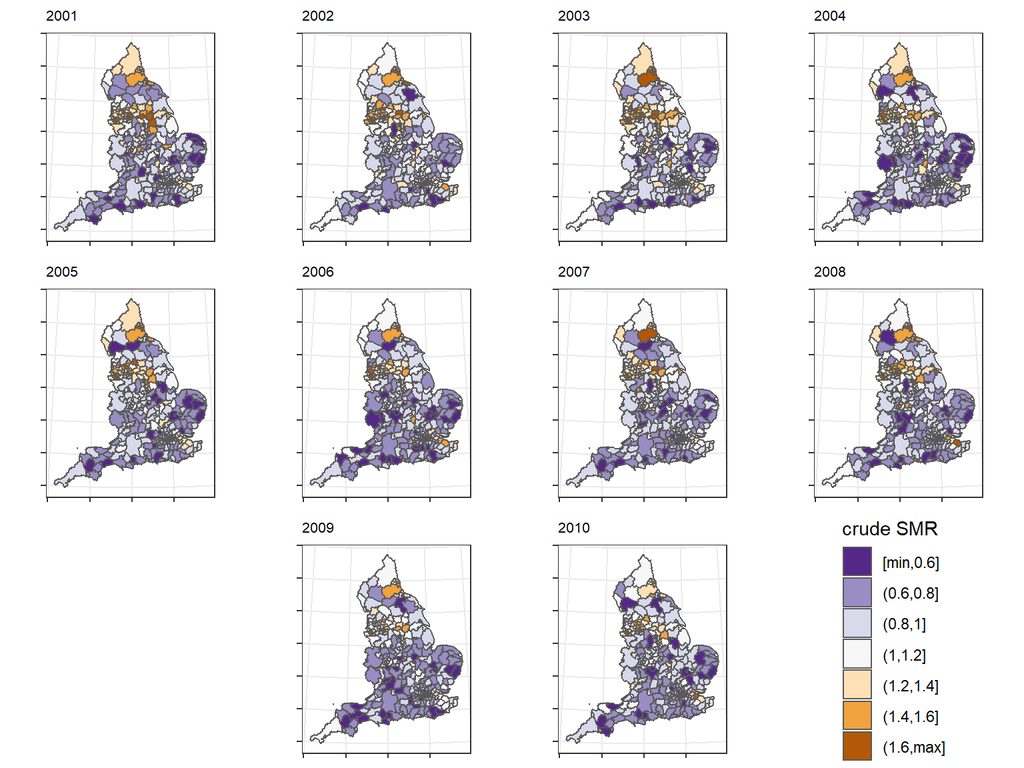

Figure 2: Crude SMR (2001 to 2010)

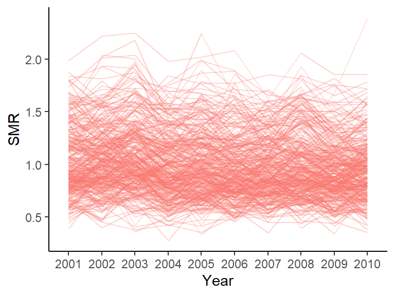

Figure 3: Crude SMRs; each line represents local unitary authority

Table 2 provides the change of top 5 LUAs of crude SMR over the 10 years. Although there are some common LUAs which appear in the table in different years such as Knowsley MCD, we also see some unusual changes over years. For example, in 2010 Corby CD was ranked top with an extremely high SMR but it was not ranked in top 5 in the previous year. Also, Knowsley MCD had an unnatural drop in 2007 compared with 2006 and 2008.

Table 2: The top 5 LUAs in terms of crude SMR

| Rank | LUA2001 | SMR2001 | LUA2002 | SMR2002 | LUA2003 | SMR2003 | LUA2004 | SMR2004 | LUA2005 | SMR2005 | LUA2006 | SMR2006 | LUA2007 | SMR2007 | LUA2008 | SMR2008 | LUA2009 | SMR2009 | LUA2010 | SMR2010 | LUA2001to2010 | SMR2001to2010 |
| --- | --- | --- | --- | --- | --- | --- | --- | --- | --- | --- | --- | --- | --- | --- | --- | --- | --- | --- | --- | --- | --- | --- |
| 1 | Knowsley MCD | 1.99 | Knowsley MCD | 2.22 | Knowsley MCD | 2.25 | Knowsley MCD | 1.98 | Barking and Dagenham LB | 2.24 | Knowsley MCD | 2.08 | Liverpool MCD | 1.85 | Knowsley MCD | 2.06 | Knowsley MCD | 1.85 | Corby CD | 2.39 | Knowsley MCD | 1.99 |
| 2 | Blackburn with Darwen UA | 1.88 | Corby CD | 2.04 | St Helens MCD | 2.18 | Blackpool UA | 1.84 | Knowsley MCD | 2.02 | Tower Hamlets LB | 1.89 | County Durham UA | 1.71 | Lincoln CD | 1.93 | Kingston upon Hull, City of UA | 1.82 | Knowsley MCD | 1.85 | Liverpool MCD | 1.77 |
| 3 | Liverpool MCD | 1.84 | St Helens MCD | 2.02 | Gateshead MCD | 2.04 | Middlesbrough UA | 1.78 | Middlesbrough UA | 1.99 | Tameside MCD | 1.89 | Middlesbrough UA | 1.69 | Bolsover CD | 1.85 | Barking and Dagenham LB | 1.76 | Liverpool MCD | 1.79 | Barking and Dagenham LB | 1.68 |
| 4 | Barnsley MCD | 1.81 | Gateshead MCD | 2.01 | Corby CD | 2.01 | Tameside MCD | 1.76 | Tower Hamlets LB | 1.98 | Corby CD | 1.86 | Tameside MCD | 1.66 | Salford MCD | 1.84 | Manchester MCD | 1.76 | Manchester MCD | 1.72 | Corby CD | 1.68 |
| 5 | Greenwich LB | 1.80 | Hyndburn CD | 1.94 | Mansfield CD | 1.97 | Hartlepool UA | 1.74 | Southwark LB | 1.90 | Stevenage CD | 1.78 | Knowsley MCD | 1.62 | Liverpool MCD | 1.81 | Salford MCD | 1.74 | Tameside MCD | 1.72 | Middlesbrough UA | 1.67 |

## 3-2. Spatio-temporal model with space-time interaction

Figure 4 shows the residual SMRs (spatial component; $e^{V_i + U_i}$) considering spatio-temporal pattern including space-time interaction over the 10 years in total. There are clusters with high SMRs in northern areas.

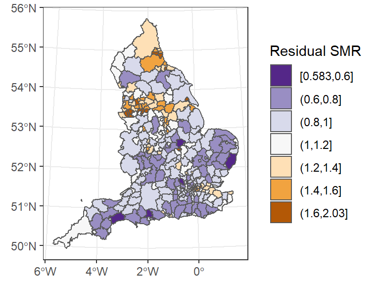

Figure 4: Smoothed SMR (spatial component)

Figure 5 provides the posterior means of smoothed SMRs considering spatio-temporal pattern ($e^{\alpha + V_{i} + U_{i} + \xi_{t} + \nu_{it}}$) over the 10 years (yearly). Appendix Figure 12 provides the posterior probability that the smoothed SMR > 1.

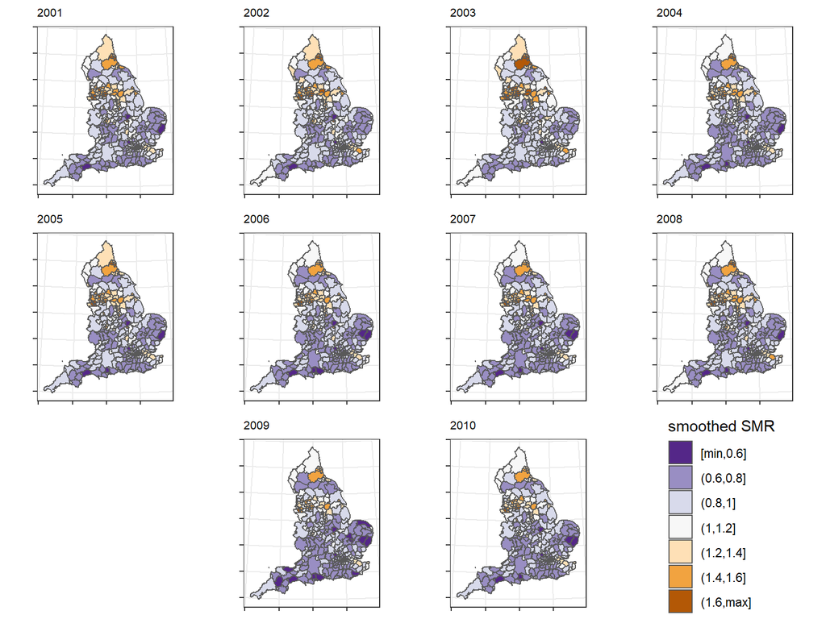

Figure 5: Smoothed SMRs (2001 to 2010)

Figure 6 is a plot of smoothed SMR of each LUA over 10 years. Blue lines represent LUAs with unusual temporal trends (defined by the probability that $\nu_{it}$ > 1 is over 0.8 at least one time point). There were 67 such LUAs. Interestingly, the LUA with highest SMR constantly over 10 years was coloured by red, meaning that this LUA followed a usual temporal trend.

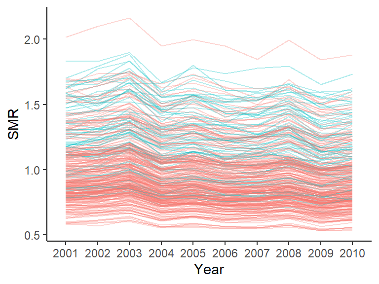

Figure 6: Posterior means of smoothed SMRs; each line represents unitary authority (blue lines = unusual temporal trend and red lines = usual temporal trend)

Table 3 provides the change of top 5 LUAs of smoothed SMR over the 10 years. Although there were changes in these top 5 areas, Knowsley MCD was constantly ranked number one. Comapared with Table 2, the LUAs listed in Table 3 were more stable.

Thus, Knowsley would appear to be the area with the highest risk, with Liverpool MCD the second. It is worth noting that St Helens MCD was ranked 3rd in 2001 but disappeared from the top 5 table since 2004, finally becoming 13th in 2010. The bottom five areas were combinations of Christchurch CD, East Devon CD, Rutland UA, Suffolk Coastal CD, Chiltern CD, and East Dorset CD (bottom table not shown). When observing this list, we found that none of the bottom five areas experienced an SMR of below 0.5.

Table 3: The top 5 LUAs in terms of smoothed SMR

| Rank | LUA2001 | SMR2001 | LUA2002 | SMR2002 | LUA2003 | SMR2003 | LUA2004 | SMR2004 | LUA2005 | SMR2005 | LUA2006 | SMR2006 | LUA2007 | SMR2007 | LUA2008 | SMR2008 | LUA2009 | SMR2009 | LUA2010 | SMR2010 |
| --- | --- | --- | --- | --- | --- | --- | --- | --- | --- | --- | --- | --- | --- | --- | --- | --- | --- | --- | --- | --- |
| 1 | Knowsley MCD | 2.02 | Knowsley MCD | 2.10 | Knowsley MCD | 2.16 | Knowsley MCD | 1.95 | Knowsley MCD | 2.00 | Knowsley MCD | 1.95 | Knowsley MCD | 1.85 | Knowsley MCD | 1.99 | Knowsley MCD | 1.84 | Knowsley MCD | 1.88 |
| 2 | Liverpool MCD | 1.83 | Liverpool MCD | 1.83 | Liverpool MCD | 1.90 | Liverpool MCD | 1.67 | Barking and Dagenham LB | 1.80 | Liverpool MCD | 1.74 | Liverpool MCD | 1.78 | Liverpool MCD | 1.79 | Liverpool MCD | 1.65 | Liverpool MCD | 1.73 |
| 3 | St Helens MCD | 1.70 | St Helens MCD | 1.79 | St Helens MCD | 1.89 | Tameside MCD | 1.66 | Liverpool MCD | 1.78 | Tameside MCD | 1.68 | Middlesbrough UA | 1.62 | Sunderland MCD | 1.69 | Manchester MCD | 1.60 | Tameside MCD | 1.62 |
| 4 | Tower Hamlets LB | 1.70 | Gateshead MCD | 1.77 | Barking and Dagenham LB | 1.84 | Middlesbrough UA | 1.66 | Middlesbrough UA | 1.73 | Tower Hamlets LB | 1.64 | Tameside MCD | 1.62 | Barking and Dagenham LB | 1.66 | Barking and Dagenham LB | 1.59 | Manchester MCD | 1.61 |
| 5 | Blackburn with Darwen UA | 1.69 | Middlesbrough UA | 1.74 | Gateshead MCD | 1.83 | Sunderland MCD | 1.63 | Tameside MCD | 1.73 | Middlesbrough UA | 1.63 | Barking and Dagenham LB | 1.60 | Salford MCD | 1.65 | Kingston upon Hull, City of UA | 1.56 | Middlesbrough UA | 1.60 |

Figure 7 shows the posterior median and 95% credible interval of temporal trends (SMR explained by temporal components) including effect from interaction. It can be seen that there was an overall downward trend with local peaks in 2003, 2005, and 2008.

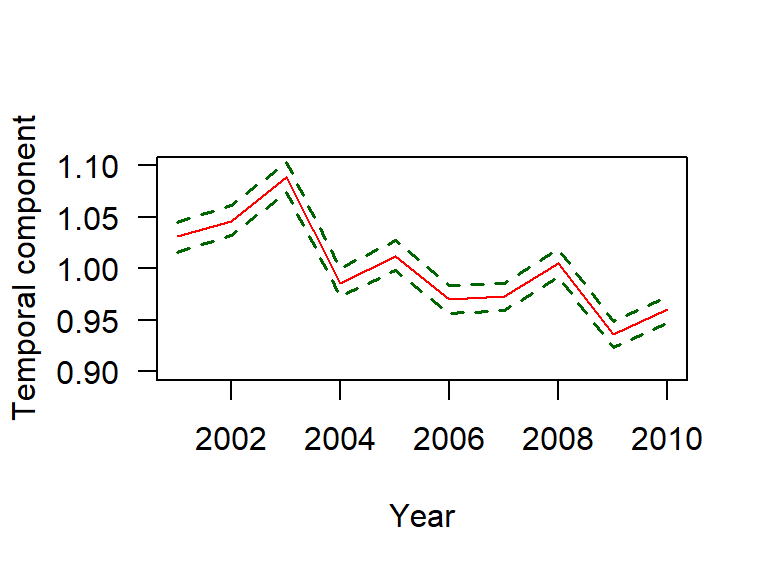

Figure 7: Posterior median of the temporal trends; dashed lines mark 95% credible intervals

Figure 8 shows the temporal components (left: main effect + interaction, right: interaction only) of each LUA. The colouring is the same as Figure 6. The presence of blue lines indicates there are LUAs with unusual temporal trends. The residual SMR explained by interaction term was up to 1.08.

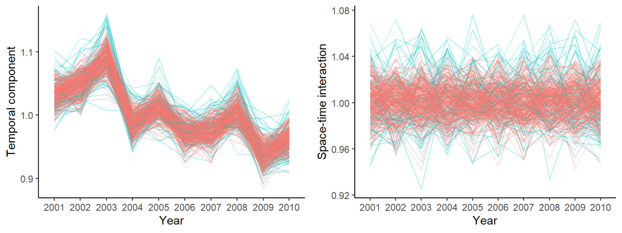

Figure 8: Posterior means of the temporal trends; each line represents unitary authority (blue lines = unusual temporal trend and red lines = usual temporal trend)

# Discussion and conclusion

# Appendix

## Models used in this project

### Spatial model (Model 1)

```r
#Project Group 2 COPD in England: A spatial model
#Model with the BYM convolution prior on the random effects

model
{
  for (i in 1 : N) {
      O[i]  ~ dpois(mu[i])
      log(mu[i]) <- log(E[i]) + alpha + U[i] +V[i]
      V[i] ~ dnorm(0, prec.v)             #  the unstructured random effects
      SMR[i] <- exp(alpha + U[i] + V[i])  #  relative risk
      residSMR[i] <- exp(U[i] + V[i])     #  the residual SMR
      PP[i] <- step(residSMR[i]-1)        #  posterior probability that residSMR is greater than 1
  }


# intrinsic CAR prior on spatial random effects U_i

  U[1:N] ~ car.normal(adj[],weights[],num[],prec.u)


# priors
  alpha ~ dflat()                      # improper uniform (-infty, +infty) prior

  prec.u ~ dgamma(0.5,0.005)           # prior on precison of spatial area random effects
  sigma2.u <- 1/prec.u                 # conditional variance of spatial area random effects

  prec.v ~ dgamma(1,0.001)             # prior on precison of unstructured area random effects
  sigma2.v <- 1/prec.v                 # conditional variance of unstructured area random effects

# other quantity of interest
  overallSMR <- exp(alpha)              # overall SMR across study region over the 10-year period

}
```

### Spatio-temporal model without interaction or unstructured temporal trend (Model 2)

```r
#A space-time model
#Separable space-time model with no interactions

model
{
  for (i in 1 : N) {
       for (t in 1:T) {
          O[i,t]  ~ dpois(mu[i,t])
          log(mu[i,t]) <- log(E[i,t]) + alpha + U[i] +V[i] + xi[t]
          SMR[i,t] <- exp(alpha + V[i] + U[i]+ xi[t])
          PPsmr[i,t] <- step(SMR[i,t]-1)
      }
      V[i] ~ dnorm(0,prec.v)            #  the unstructured random effects
      residSMRsp[i] <- exp(U[i] + V[i])    #  the spatial residual SMR
      PPsp[i] <- step(residSMRsp[i]-1)       #  posterior probability
  }

# intrinsic CAR prior on spatial random effects
  U[1:N] ~ car.normal(adj[], weights[], num[], prec.u)


# intrinsic CAR prior on temporal random effects
  xi[1:T] ~ car.normal(adj.tm[], weights.tm[], num.tm[], prec.xi)

   # Weight matrix and adjacency matrix corresponding to RW(1) prior

    for(t in 1:1) {
        weights.tm[t] <- 1;          adj.tm[t] <- t+1;     num.tm[t] <- 1
    }
    for(t in 2:(T-1)) {
          weights.tm[2+(t-2)*2] <- 1;      adj.tm[2+(t-2)*2] <- t-1
        weights.tm[3+(t-2)*2] <- 1;       adj.tm[3+(t-2)*2] <- t+1;      num.tm[t] <- 2
    }
    for(t in T:T) {
        weights.tm[(T-2)*2 + 2] <- 1;      adj.tm[(T-2)*2 + 2] <- t-1;    num.tm[t] <- 1
    }


# priors:
  alpha  ~ dflat()                     # improper uniform (-infty, +infty) prior

  prec.u ~ dgamma(0.5,0.005)           # prior on precison of spatial area random effects
  sigma2.u <- 1/prec.u                 # conditional variance of spatial area random effects
  prec.v ~ dgamma(1, 0.001)            # prior on precison of unstructured area random effects
  sigma2.v <- 1/prec.v                 # conditional variance of unstructured area random effects
  prec.xi ~ dgamma(0.5, 0.005)         # prior on precison of temporal random effects
  sigma2.xi <- 1/prec.xi               # conditional variance of temporal random effects

# other quantities of interest
  overallSMR <- exp(alpha)                          # overall SMR across study region over the 10-year period
                                                                                                    #risks due to spatial effects
  for (t in 1:T) {
      residSMRtm[t] <- exp(xi[t])   #  the temporal residual SMR
  }
}
```

### Spatio-temporal model without interaction but with unstructured temporal trend (Model 3)

```r
#A space-time model
#Separable space-time model with no interactions but with unstructured temporal trend

model
{
  for (i in 1 : N) {
       for (t in 1:T) {
          O[i,t]  ~ dpois(mu[i,t])
          log(mu[i,t]) <- log(E[i,t]) + alpha + U[i] +V[i] + xi[t] + gam[t]
          SMR[i,t] <- exp(alpha + V[i] + U[i]+ xi[t] + gam[t])
          PPsmr[i,t] <- step(SMR[i,t]-1)
      }
      V[i] ~ dnorm(0,prec.v)            #  the unstructured random effects
      residSMRsp[i] <- exp(U[i] + V[i])    #  the spatial residual SMR
      PPsp[i] <- step(residSMRsp[i]-1)       #  posterior probability
  }

# intrinsic CAR prior on spatial random effects
  U[1:N] ~ car.normal(adj[], weights[], num[], prec.u)


# intrinsic CAR prior on temporal random effects
  xi[1:T] ~ car.normal(adj.tm[], weights.tm[], num.tm[], prec.xi)

   # Weight matrix and adjacency matrix corresponding to RW(1) prior

    for(t in 1:1) {
        weights.tm[t] <- 1;          adj.tm[t] <- t+1;     num.tm[t] <- 1
    }
    for(t in 2:(T-1)) {
          weights.tm[2+(t-2)*2] <- 1;      adj.tm[2+(t-2)*2] <- t-1
        weights.tm[3+(t-2)*2] <- 1;       adj.tm[3+(t-2)*2] <- t+1;      num.tm[t] <- 2
    }
    for(t in T:T) {
        weights.tm[(T-2)*2 + 2] <- 1;      adj.tm[(T-2)*2 + 2] <- t-1;    num.tm[t] <- 1
    }

for (t in 1:T){
  gam[t] ~ dnorm(0,prec.gamma)
}

# priors:
  alpha  ~ dflat()                     # improper uniform (-infty, +infty) prior

  prec.u ~ dgamma(0.5,0.005)           # prior on precison of spatial area random effects
  sigma2.u <- 1/prec.u                 # conditional variance of spatial area random effects
  prec.v ~ dgamma(1, 0.001)            # prior on precison of unstructured area random effects
  sigma2.v <- 1/prec.v                 # conditional variance of unstructured area random effects
  prec.xi ~ dgamma(0.5, 0.005)         # prior on precison of temporal random effects
  sigma2.xi <- 1/prec.xi               # conditional variance of temporal random effects
  prec.gamma ~ dgamma(0.5, 0.005)      # prior on precison of temporal unstructured random effects
  sigma2.gamma <- 1/prec.gamma         # conditional variance of temporal unstructured random effects


# other quantities of interest
  overallSMR <- exp(alpha)                          # overall SMR across study region over the 10-year period
                                                                                                    #risks due to spatial effects
  for (t in 1:T) {
      residSMRtm[t] <- exp(xi[t] + gam[t])   #  the temporal residual SMR
  }
}
```

### Spatio-temporal model with interaction (Model 4 - finally selected model)

```r
#A space-time model
#Separable space-time model with interactions

model
{
  for (i in 1:N) {
       for (t in 1:T) {
          O[i,t]  ~ dpois(mu[i,t])
          log(mu[i,t]) <- log(E[i,t]) + alpha + U[i] + V[i] + xi[t] + nu[i,t]
          nu[i,t] ~ dnorm(0, prec.nu)    #space-time interactions
          SMR[i,t] <- exp(alpha + V[i] + U[i] + xi[t] + nu[i,t])
          PPsmr[i,t] <- step(SMR[i,t]-1)
      }
      V[i] ~ dnorm(0,prec.v)            #  the unstructured random effects
      residSMRsp[i] <- exp(U[i] + V[i])    #  the spatial residual SMR
      PPsp[i] <- step(residSMRsp[i]-1)       #  posterior probability
  }

# intrinsic CAR prior on spatial random effects
  U[1:N] ~ car.normal(adj[], weights[], num[], prec.u)


# intrinsic CAR prior on temporal random effects
  xi[1:T] ~ car.normal(adj.tm[], weights.tm[], num.tm[], prec.xi)

   # Weight matrix and adjacency matrix corresponding to RW(1) prior

    for(t in 1:1) {
        weights.tm[t] <- 1;          adj.tm[t] <- t+1;     num.tm[t] <- 1
    }
    for(t in 2:(T-1)) {
          weights.tm[2+(t-2)*2] <- 1;      adj.tm[2+(t-2)*2] <- t-1
        weights.tm[3+(t-2)*2] <- 1;       adj.tm[3+(t-2)*2] <- t+1;      num.tm[t] <- 2
    }
    for(t in T:T) {
        weights.tm[(T-2)*2 + 2] <- 1;      adj.tm[(T-2)*2 + 2] <- t-1;    num.tm[t] <- 1
    }


# priors:
  alpha  ~ dflat()                     # improper uniform (-infty, +infty) prior

  prec.u ~ dgamma(0.5,0.005)           # prior on precison of spatial area random effects
  sigma2.u <- 1/prec.u                 # conditional variance of spatial area random effects
  prec.v ~ dgamma(1, 0.001)            # prior on precison of unstructured area random effects
  sigma2.v <- 1/prec.v                 # conditional variance of unstructured area random effects
  prec.xi ~ dgamma(0.5, 0.005)         # prior on precison of temporal random effects
  sigma2.xi <- 1/prec.xi               # conditional variance of temporal random effects
  prec.nu ~ dgamma(0.5, 0.0005)
  sigma2.nu <- 1/prec.nu               # variance of space-time interactions

# other quantities of interest
  overallSMR <- exp(alpha)                          # overall SMR across study region over the 10-year period
                                                                                                    #risks due to spatial effects
  for (t in 1:T) {
      residSMRtm[t] <- exp(xi[t])   #  the temporal residual SMR
  }

  for (i in 1:N) {
       for (t in 1:T) {
          residSMRtmintonly[i,t] <- exp(nu[i,t])
          residSMRtmint[i,t] <- exp(xi[t] + nu[i,t])
          PPint[i,t] <- step(residSMRtmintonly[i,t]-1)
      }
  }

}
```

## Results not shown in the main text

### Spatial Model (Model 1)

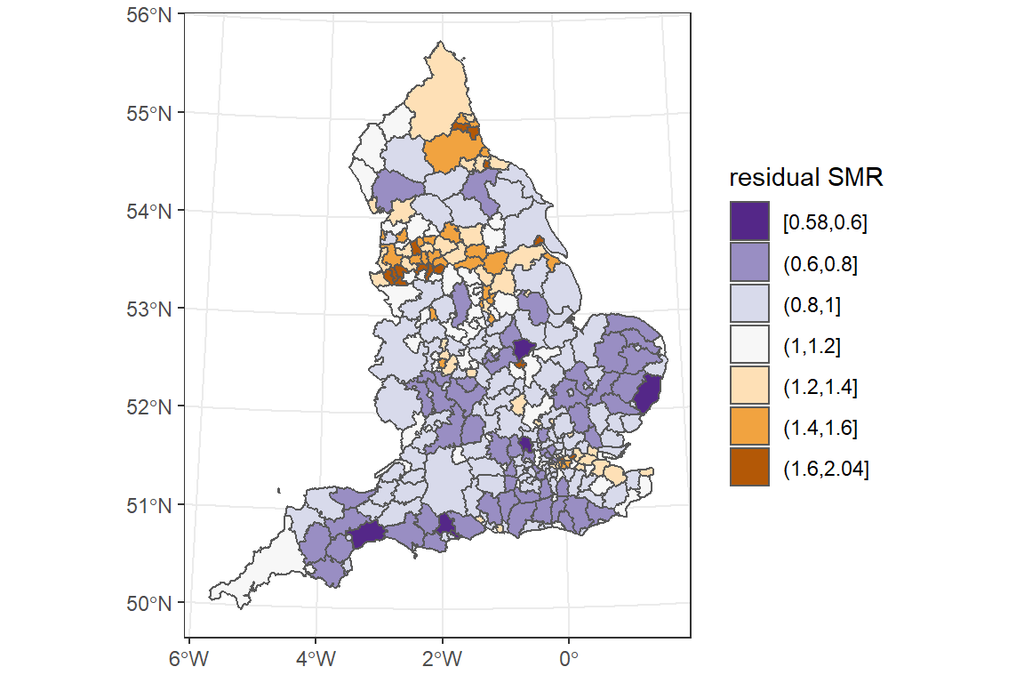

Appendix Figure 1: residual SMR (2001 to 2010 in total)

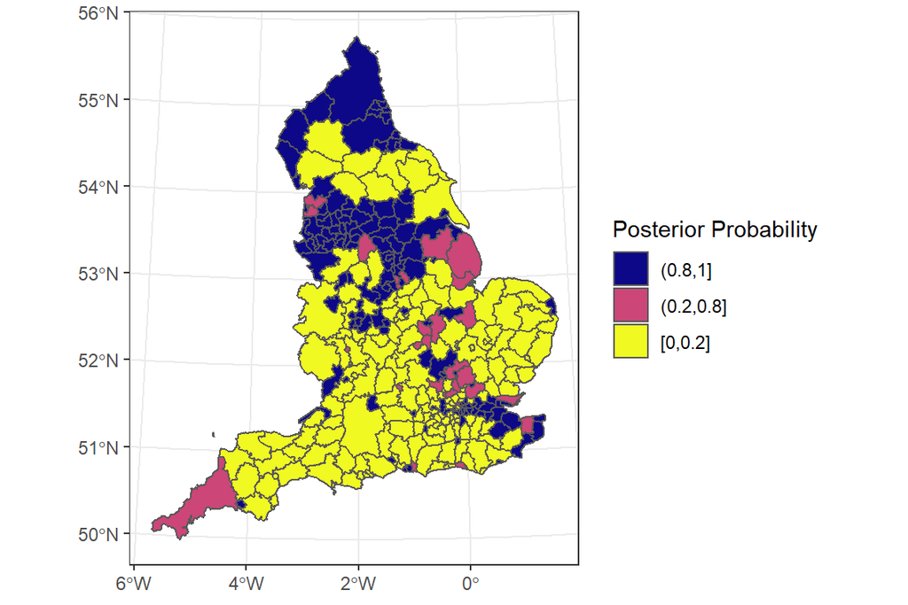

Appendix Figure 2: Posterior probability that the residual SMRs are > 1

### Spatio-temporal model without sapce-time interaction (Model 2)

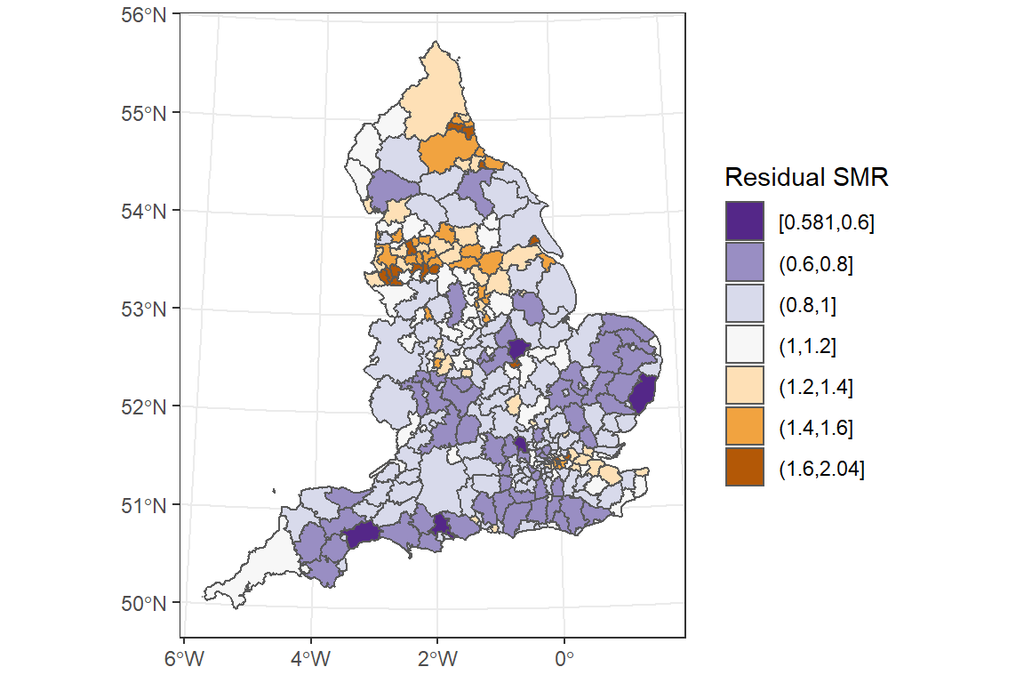

Appendix Figure 3: Residual SMR (spatial component)

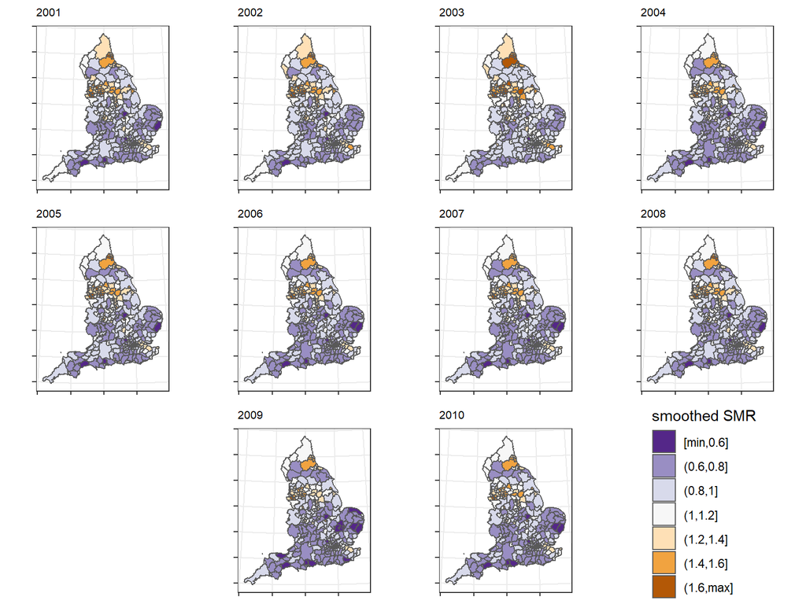

Appendix Figure 4: smoothed SMR (2001 to 2010)

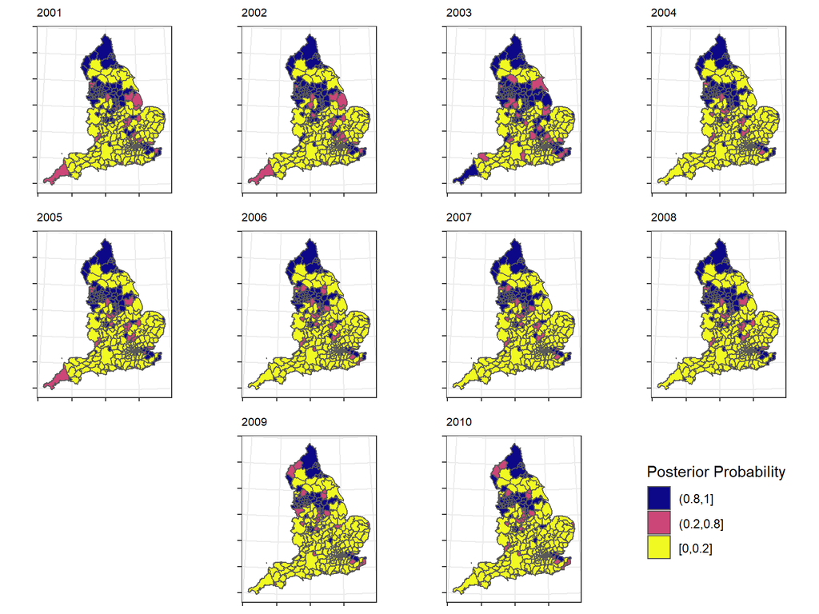

Appendix Figure 5: Posteriot probability of SMR > 1 (2001 to 2010)

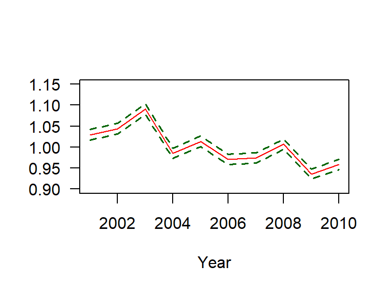

Appendix Figure 6: Posterior median of the temporal trends; dashed lines mark 95% credible intervals

### Spatio-temporal model without sapce-time interaction but with unstructured temporal variation (Model 3)

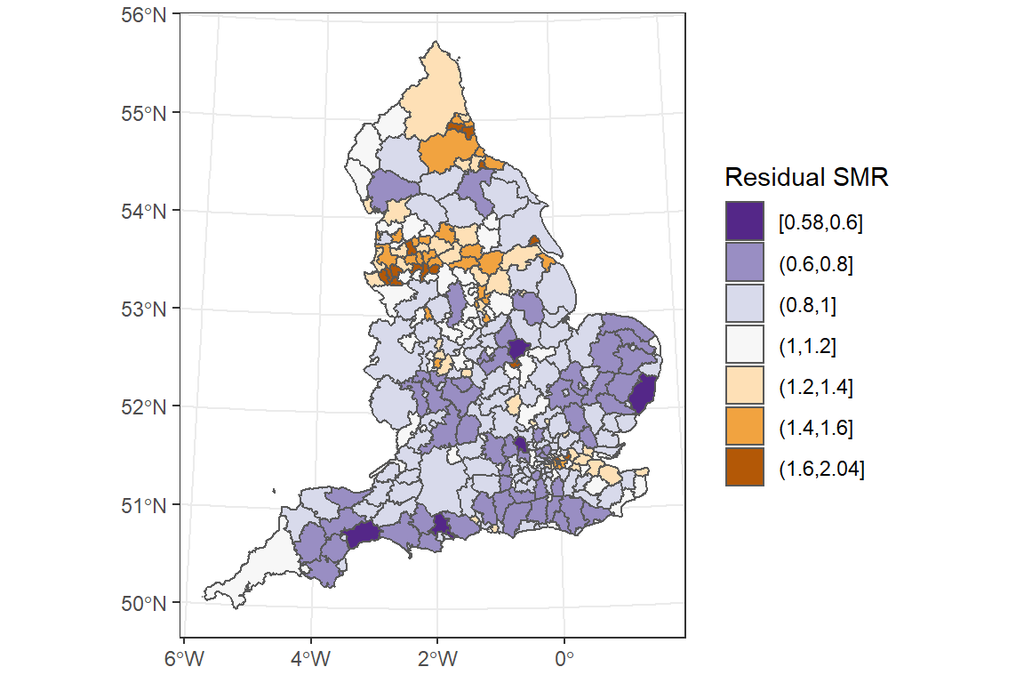

Appendix Figure 7: Residual SMR (spatial component)

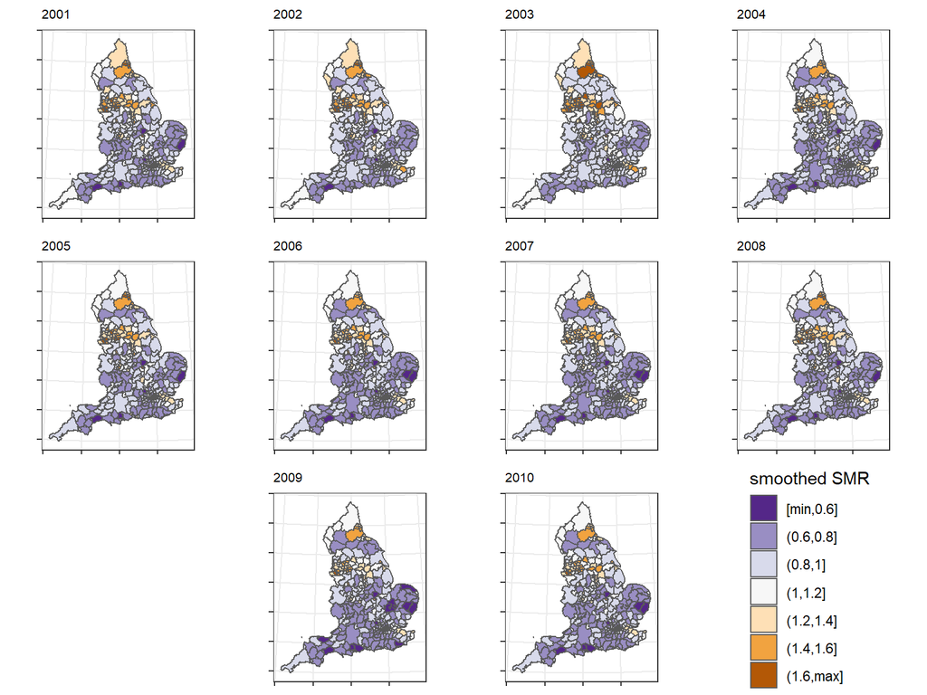

Appendix Figure 8: smoothed SMR (2001 to 2010)

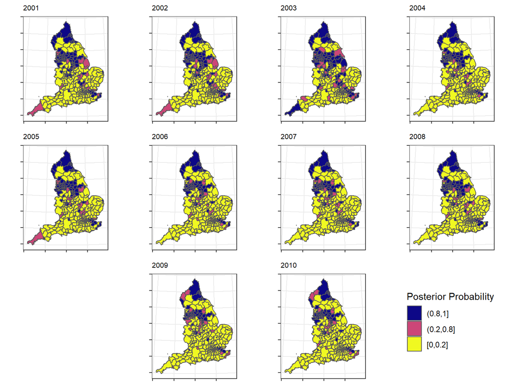

Appendix Figure 9: Posteriot probability of SMR > 1 (2001 to 2010)

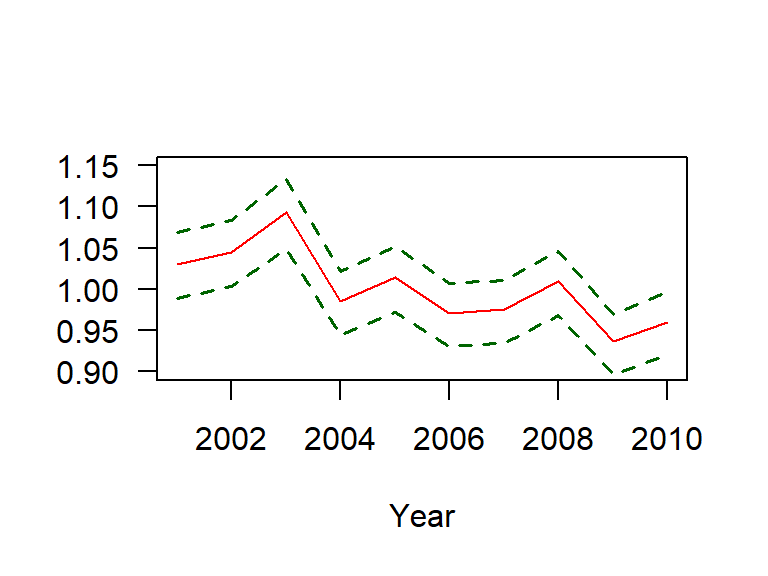

Appendix Figure 10: Posterior median of the temporal trends; dashed lines mark 95% credible intervals

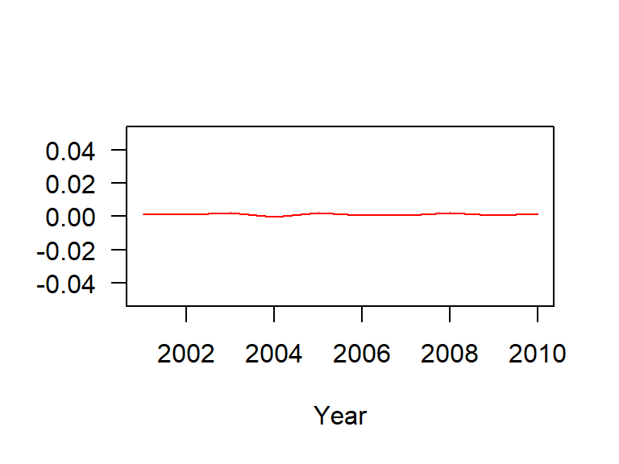

Appendix Figure 11: Difference in posterior median of the temporal trends between models with and without unstructured temporal pattern

- The posterior probabilities that SMR > 1 considering spatio-temporal pattern with interaction of are and time over the 10 years (yearly) is below.

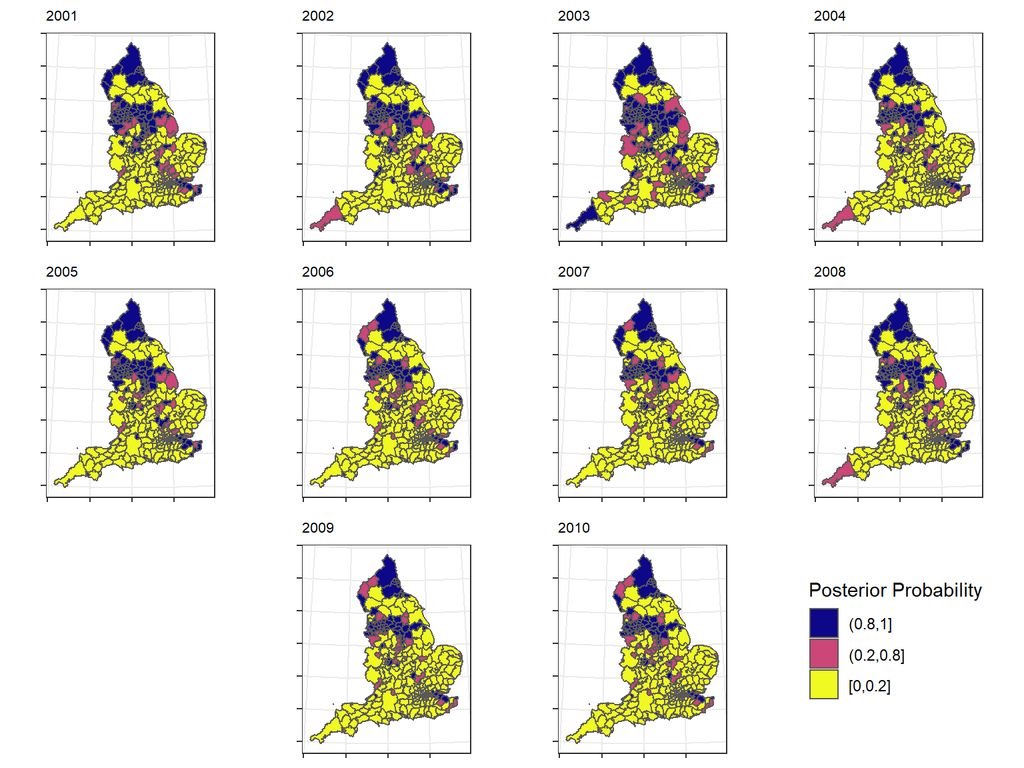

Appendix Figure 12: Posteriot probability of SMR > 1 (2001 to 2010)

# References

Agusti, Alvar, Peter MA Calverley, Bartolome Celli, Harvey O Coxson, Lisa D Edwards, David A Lomas, William MacNee, et al. 2010. “Characterisation of Copd Heterogeneity in the Eclipse Cohort.” *Respiratory Research* 11 (1): 122.

Boulieri, Areti, Anna Hansell, and Marta Blangiardo. 2016. “Investigating Trends in Asthma and Copd Through Multiple Data Sources: A Small Area Study.” *Spatial and Spatio-Temporal Epidemiology* 19: 28–36.

Hacking, John M, Sara Muller, and Iain E Buchan. 2011. “Trends in Mortality from 1965 to 2008 Across the English North-South Divide: Comparative Observational Study.” *Bmj* 342: d508.

Hansell, A, J Hollowell, R McNiece, T Nichols, and D Strachan. 2003. “Validity and Interpretation of Mortality, Health Service and Survey Data on Copd and Asthma in England.” *European Respiratory Journal* 21 (2): 279–86.

Hemming, Deborah, A Colman, P James, N Kaye, P Marno, D McNeall, R McCarthy, et al. 2009. “Framework for Copd Forecasting in the Uk Using Weather and Climate Change Predictions.” In *IOP Conference Series: Earth and Environmental Science*, 6:142021. 14.

Holt, James B, Xingyou Zhang, Letitia Presley-Cantrell, and Janet B Croft. 2011. “Geographic Disparities in Chronic Obstructive Pulmonary Disease (Copd) Hospitalization Among Medicare Beneficiaries in the United States.” *International Journal of Chronic Obstructive Pulmonary Disease* 6: 321.

Johnson, Olatunji, Peter Diggle, Michael Pearson, Tim Gatheral, Jo Knight, and Emanuele Giorgi. 2020. “Spatio-Temporal Modelling of Incidence in Copd Emergency Admissions in an Area of Northwest England from 2012 to 2018.” *Geostatistical Methods for Modelling Spatially Aggregated Data*, 87.

Knorr-Held, Leonhard. 2000. “Bayesian Modelling of Inseparable Space-Time Variation in Disease Risk.” *Statistics in Medicine* 19 (17-18): 2555–67.

Lipton, R, and R Banerjee. 2006. “The Geography of Chronic Obstructive Pulmonary Disease in California, 1993 & 1999: Using a Novel Method to Transform Zip Code Level Data to a Uniform Grid Structure.” In *American Journal of Epidemiology*, 163:S28–S28. 11. OXFORD UNIV PRESS INC JOURNALS DEPT, 2001 EVANS RD, CARY, NC 27513 USA.

Nandram, Balgobin, J Sedransk, and Linda Williams Pickle. 2000. “Bayesian Analysis and Mapping of Mortality Rates for Chronic Obstructive Pulmonary Disease.” *Journal of the American Statistical Association* 95 (452): 1110–8.

Wells, Claudia, and Emma Gordon. 2008. “Geographical Variations in Premature Mortality in England and Wales, 1981–2006.” *Health Stat Q* 38: 6–18.